# Analysis of TMT data from MS2 and MS3 methods

Christopher Hughes

### Description

This file contains the code for processing the search and quantification output files from the analysis of MS2 and MS3 methods for the acquisition of TMT samples. **These data were used to make portions of Figure 3, 4, S-8.**

- MGF files were generated using RawQuant.
- The data were searched using SearchCLI and PeptideShakerCLI.
- Raw files were quantified with RawQuant.

### Analysis

These are the libraries we will use somewhere in the analysis.

```r
library(Biostrings)
library(dplyr)
library(ggplot2)
library(RColorBrewer)
library(cowplot)
library(reshape)
library(data.table)
library(limma)
```

First we can look at the actual scan metrics. How do the numbers of MS2 change across the acquisition types and numbers of injections?

```r
#first grab the MS2 output files from RawQuant for each analysis type
ms2_quant_files = list.files('/projects/ptx_analysis/chughes/projects-current/raw-quant/ms2-ms3/quant-output',pattern='*MS2ParseData.txt',full.names=TRUE)

ms2_data = data.frame() #data storage object
#iterate over the quantification files to get the numbers of MS2 scans
for (i in 1:length(ms2_quant_files)){
  ms2_in = read.table(ms2_quant_files[i],header=TRUE,sep='\t') #read in the file
  ms2_in$fraction = sub(".*?TMT6_(.*?)_[1-9].*", "\\1", ms2_quant_files[i]) #add a fraction column
  ms2_data = rbind(ms2_data,ms2_in) #bind the data
}
saveRDS(ms2_data,'/projects/ptx_analysis/chughes/projects-current/raw-quant/ms2-ms3/Routput/all-fractions-ms2-data.rds') #save the data
msms_table = as.data.frame(table(ms2_data$fraction)) #summarise the data to count the MS2 in each fraction
#plot the data
msms_plot = ggplot(msms_table, aes(x = Var1, y = Freq)) +
  geom_point(colour='grey60',size=2) +
  labs(x = "fraction", y = 'number of msms', title = 'msms acquisition across fractions') +
  theme(axis.text.x = element_text(size = 9)) +
  geom_hline(yintercept=mean(msms_table$Freq,na.rm=TRUE),color = brewer.pal(6,'RdBu')[1])
  #scale_y_continuous(breaks = seq(0,65000,5000),limits=c(40000,65000)) +
  #scale_x_continuous(breaks = seq(1,15,1))
msms_plot #call the plot
save_plot('/projects/ptx_analysis/chughes/projects-current/raw-quant/ms2-ms3/Routput/number-of-ms2-scans-across-all-methods.pdf',msms_plot) #save the plot
message('mean number of msms = ',mean(msms_table$Freq,na.rm=TRUE))
```

Now we want to calculate what this does to the number of unique peptide matches. Need to read the identification data for this. The below code builds two large data matrices that contain all the ms2 quant and identification data, and another for the ms3 data. The data matrices are saved for later use.

```r
####make a database index for adding annotation data later to the identification data
humanDB = readAAStringSet('/projects/ptx_analysis/chughes/databases/uniprot_human-crap-oct2017-FWD.fasta')
#make an annotation index from humanDB
humanIndex = data.frame('meta' = names(humanDB))
humanIndex$accession = sub(".*?\\|(.*?)\\|.*", "\\1", humanIndex$meta) #grab the accession
humanIndex$gene = sub(".*?GN=(.*?) .*", "\\1", humanIndex$meta) #grab the gene name
humanIndex$species = sub(".*?OS=(.*?) [GP].*", "\\1", humanIndex$meta) #grab the species
humanIndex = humanIndex[,2:4] #grab the important data
###iterate over the identification and quantification data to build a single massive id + quant object
###quant fies for ms2 files
ms2_quant_files = list.files('/projects/ptx_analysis/chughes/projects-current/raw-quant/ms2-ms3/quant-output', pattern='.*fusion-ms2.*QuantData.txt',full.names=TRUE) #quant data from RawQuant
ms2_quant_data = data.frame() #data storage object
#iterate over the quant files
for (i in 1:length(ms2_quant_files)){
  quant_in = read.table(ms2_quant_files[i],header=TRUE,sep='\t') #grab the input file
  #change values that are zero to NA
  quant_in[,9:44][quant_in[,9:44] == 0] = NA
  #rearrange the data frame
  quant_meta = quant_in[,c('PrecursorMass','ScanNumber','MS1ScanNumber','RetentionTime',
                           'PrecursorCharge','MS2IonInjectionTime','MS1Interference')]
  quant_exprs = quant_in[,c('tmt126_intensity','tmt127N_intensity','tmt128C_intensity','tmt129N_intensity',
                            'tmt130C_intensity','tmt131_intensity','tmt126_noise','tmt127N_noise',
                            'tmt128C_noise','tmt129N_noise','tmt130C_noise','tmt131_noise')]
  #calculate signal to noise
  quant_sn = quant_exprs[,c(1:6)] / quant_exprs[,c(7:12)] #signal-to-noise calculation
  quant_sn$totalIntensity = rowSums(quant_exprs[,1:6],na.rm=TRUE) #total intensity calculation
  quant_sn$totalSN = rowSums(quant_sn[,1:6],na.rm=TRUE) #total signal-to-noise calculation
  quant_sn$totalNoise = rowSums(quant_exprs[,7:12],na.rm=TRUE) #total noise calculation
  quant_sn$totalNA = rowSums(is.na(quant_sn[,1:6])) #information about missing values
  quant_meta$fraction = sub(".*?ms2_(.*?)_Quant.*", "\\1", ms2_quant_files[i]) #add the fraction column
  quant_meta$replicate = sub(".*?TMT6_(.*?)_[1-9].*", "\\1", ms2_quant_files[i]) #add a replicate column
  quant_matrix = cbind(quant_meta,quant_sn) #bind the information and quantification together
  ms2_quant_data = rbind(ms2_quant_data, quant_matrix) #bind into a single frame
}
###MS2 identification results
ms2_psm_files = list.files('/projects/ptx_analysis/chughes/projects-current/raw-quant/ms2-ms3/reports-output', pattern='ms2.*Default_PSM_Report.txt',full.names=TRUE)
ms2_psm_data = data.frame() #data storage object
for (i in 1:length(ms2_psm_files)){
###this first section handles the identification data
  psm_in = read.table(ms2_psm_files[i],header=TRUE,sep='\t') #input file
  psm_f1 = psm_in %>%
    dplyr::select(Protein.s., Sequence, Spectrum.File, Spectrum.Title, m.z, Identification.Charge) %>% #select columns
    dplyr::mutate(Spectrum.Title, scan_num = sub(".*?spectrum (.*?)", "\\1", Spectrum.Title)) %>% #parse out the scan number
    dplyr::mutate(Identification.Charge, id_charge = gsub("[^0-9]", "", Identification.Charge)) %>% #parse out the charge
    dplyr::mutate(Spectrum.Title, fraction = sub(".*?ms2_(.*?)_MGF.*", "\\1", Spectrum.File)) %>% #parse the fraction
    dplyr::mutate(Spectrum.Title, replicate = sub(".*?TMT6_(.*?)_[1-9].*", "\\1", Spectrum.File)) %>% #parse the fraction
    dplyr::select(Protein.s., Sequence, scan_num, m.z, id_charge, fraction, replicate) %>% #select new columns
    dplyr::mutate(Protein.s., first_accession = sapply(strsplit(as.character(Protein.s.),"\\,"), `[`, 1)) #parse the accession
  #adjust the column names
  colnames(psm_f1) = c('accession_groups','sequence','ScanNumber','id_precursor_mz','id_charge','fraction','replicate','accession')
  psm_f2 = merge(psm_f1,humanIndex,by='accession',all.x=TRUE) #add the descriptive data
  psm_f3 = dplyr::filter(psm_f2, !grepl('CONT', accession)) #remove contaminant hits
  ms2_psm_data = rbind(ms2_psm_data,psm_f3)
}
ms2_idset = merge(ms2_psm_data,ms2_quant_data,by=c('ScanNumber','replicate','fraction'))
saveRDS(ms2_idset,'/projects/ptx_analysis/chughes/projects-current/raw-quant/ms2-ms3/Routput/all-ms2-id-quant-data.rds')
###quant fies for ms3 files
ms3_quant_files = list.files('/projects/ptx_analysis/chughes/projects-current/raw-quant/ms2-ms3/quant-output', pattern='.*fusion-ms3.*QuantData.txt',full.names=TRUE) #quant data from RawQuant
ms3_quant_data = data.frame() #data storage object
#iterate over the quant files
for (i in 1:length(ms3_quant_files)){
  quant_in = read.table(ms3_quant_files[i],header=TRUE,sep='\t') #grab the input file
  #change values that are zero to NA
  quant_in[,11:66][quant_in[,11:66] == 0] = NA
  #rearrange the data frame
  quant_meta = quant_in[,c('PrecursorMass','MS2ScanNumber','MS1ScanNumber','RetentionTime',
                           'PrecursorCharge','MS2IonInjectionTime','MS1Interference')]
  quant_exprs = quant_in[,c('tmt126_intensity','tmt127N_intensity','tmt128C_intensity','tmt129N_intensity',
                            'tmt130C_intensity','tmt131_intensity','tmt126_noise','tmt127N_noise',
                            'tmt128C_noise','tmt129N_noise','tmt130C_noise','tmt131_noise')]
  #calculate signal to noise
  quant_sn = quant_exprs[,c(1:6)] / quant_exprs[,c(7:12)] #signal-to-noise calculation
  quant_sn$totalIntensity = rowSums(quant_exprs[,1:6],na.rm=TRUE) #total intensity calculation
  quant_sn$totalSN = rowSums(quant_sn[,1:6],na.rm=TRUE) #total signal-to-noise calculation
  quant_sn$totalNoise = rowSums(quant_exprs[,7:12],na.rm=TRUE) #total noise calculation
  quant_sn$totalNA = rowSums(is.na(quant_sn[,1:6])) #information about missing values
  quant_meta$fraction = sub(".*?ms3_(.*?)_Quant.*", "\\1", ms3_quant_files[i]) #add the fraction column
  quant_meta$replicate = sub(".*?TMT6_(.*?)_[1-9].*", "\\1", ms3_quant_files[i]) #add a replicate column
  quant_matrix = cbind(quant_meta,quant_sn) #bind the information and quantification together
  ms3_quant_data = rbind(ms3_quant_data, quant_matrix) #bind into a single frame
}
colnames(ms3_quant_data)[2] = 'ScanNumber' #change the scan number identification column name
###MS3 identification results
ms3_psm_files = list.files('/projects/ptx_analysis/chughes/projects-current/raw-quant/ms2-ms3/reports-output', pattern='ms3.*Default_PSM_Report.txt',full.names=TRUE)
ms3_psm_data = data.frame() #data storage object
for (i in 1:length(ms3_psm_files)){
###this first section handles the identification data
  psm_in = read.table(ms3_psm_files[i],header=TRUE,sep='\t') #input file
  psm_f1 = psm_in %>%
    dplyr::select(Protein.s., Sequence, Spectrum.File, Spectrum.Title, m.z, Identification.Charge) %>% #select columns
    dplyr::mutate(Spectrum.Title, scan_num = sub(".*?spectrum (.*?)", "\\1", Spectrum.Title)) %>% #parse out the scan number
    dplyr::mutate(Identification.Charge, id_charge = gsub("[^0-9]", "", Identification.Charge)) %>% #parse out the charge
    dplyr::mutate(Spectrum.Title, fraction = sub(".*?ms3_(.*?)_MGF.*", "\\1", Spectrum.File)) %>% #parse the fraction
    dplyr::mutate(Spectrum.Title, replicate = sub(".*?TMT6_(.*?)_[1-9].*", "\\1", Spectrum.File)) %>% #parse the fraction
    dplyr::select(Protein.s., Sequence, scan_num, m.z, id_charge, fraction, replicate) %>% #select new columns
    dplyr::mutate(Protein.s., first_accession = sapply(strsplit(as.character(Protein.s.),"\\,"), `[`, 1)) #parse the accession
  #adjust the column names
  colnames(psm_f1) = c('accession_groups','sequence','ScanNumber','id_precursor_mz','id_charge','fraction','replicate','accession')
  psm_f2 = merge(psm_f1,humanIndex,by='accession',all.x=TRUE) #add the descriptive data
  psm_f3 = dplyr::filter(psm_f2, !grepl('CONT', accession)) #remove contaminant hits
  ms3_psm_data = rbind(ms3_psm_data,psm_f3)
}
ms3_idset = merge(ms3_psm_data,ms3_quant_data,by=c('ScanNumber','replicate','fraction'))
saveRDS(ms3_idset,'/projects/ptx_analysis/chughes/projects-current/raw-quant/ms2-ms3/Routput/all-ms3-id-quant-data.rds')
```

Now we can look at the impact of the ms2 or ms3 scanning on the numbers of unique peptides that have reliable quantification.

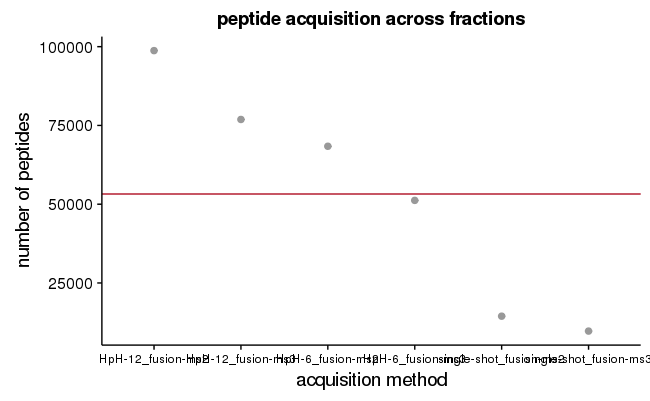

```r
ms2_set = readRDS('/projects/ptx_analysis/chughes/projects-current/raw-quant/ms2-ms3/Routput/all-ms2-id-quant-data.rds') #grab the ms2 data
ms3_set = readRDS('/projects/ptx_analysis/chughes/projects-current/raw-quant/ms2-ms3/Routput/all-ms3-id-quant-data.rds') #grab the ms3 data
ms_set = rbind(ms2_set,ms3_set) #bind all of the data together
#aggregate to unique peptides
ms_agg <- setDT(ms_set)[, lapply(.SD,sum,na.rm=TRUE),by=.(sequence,fraction,replicate),.SDcols=c('totalSN')] #collapse by PSM
setDF(ms_agg) # convert back to dataframe
peps_table = as.data.frame(table(ms_agg$replicate)) #summarise the data to count the peps in each fraction
#plot the data
peps_plot = ggplot(peps_table, aes(x = Var1, y = Freq)) +
  geom_point(colour='grey60',size=2) +
  labs(x = "acquisition method", y = 'number of peptides', title = 'peptide acquisition across fractions') +
  theme(axis.text.x = element_text(size = 9)) +
  geom_hline(yintercept=mean(peps_table$Freq,na.rm=TRUE),color = brewer.pal(6,'RdBu')[1])
peps_plot #call the plot
save_plot('/projects/ptx_analysis/chughes/projects-current/raw-quant/ms2-ms3/Routput/number-of-peptides-across-all-methods.pdf',peps_plot) #save the plot
```

```r
message('mean number of peptides = ',mean(peps_table$Freq,na.rm=TRUE))
```

```
mean number of peptides = 53238.8333333333
```

The PSM rate seems to increase as the analysis time gets shorter whereas the MS2 rate remains unchanged. The answer to this maybe be in the numbers of PSMs being identified per peptide. I would expect this to increase for MS2, but remain constant for MS3.

```r
ms2_set = readRDS('/projects/ptx_analysis/chughes/projects-current/raw-quant/ms2-ms3/Routput/all-ms2-id-quant-data.rds') #grab the ms2 data
ms3_set = readRDS('/projects/ptx_analysis/chughes/projects-current/raw-quant/ms2-ms3/Routput/all-ms3-id-quant-data.rds') #grab the ms3 data
ms_set = rbind(ms2_set,ms3_set) #bind all of the data together
#so this is PSM data. Need to do two separate aggregations.
ms_set$PSM = 1 #add a PSM counter
ms_psm <- setDT(ms_set)[, lapply(.SD,sum,na.rm=TRUE),by=.(accession,sequence,replicate),.SDcols=c('PSM')] #collapse by PSM
ms_psm_per <- ms_psm[, lapply(.SD,mean,na.rm=TRUE),by=.(replicate),.SDcols=c('PSM')] #collapse by method, taking the mean this time
setDF(ms_psm_per) # convert back to dataframe
ms_psm$PEPS = 1 #add a peptide counter
ms_pro <- setDT(ms_psm)[, lapply(.SD,sum,na.rm=TRUE),by=.(accession,replicate),.SDcols=c('PEPS')] #collapse by peptide
ms_pro_per <- ms_pro[, lapply(.SD,mean,na.rm=TRUE),by=.(replicate),.SDcols=c('PEPS')] #can also do peptides per protein
setDF(ms_pro_per) # convert back to dataframe
```

Hmm…this doesn’t seem to be the case, so it is more likely that MS2 is just sampling more stuff that just isn’t identified. Runs out of good hits to capture. How do the methods do for identification of the synthetic peptides.

```r
ms2_set = readRDS('/projects/ptx_analysis/chughes/projects-current/raw-quant/ms2-ms3/Routput/all-ms2-id-quant-data.rds') #grab the ms2 data
ms3_set = readRDS('/projects/ptx_analysis/chughes/projects-current/raw-quant/ms2-ms3/Routput/all-ms3-id-quant-data.rds') #grab the ms3 data
ms_set = rbind(ms2_set,ms3_set) #bind all of the data together
speps = read.table('/projects/ptx_analysis/chughes/projects-current/raw-quant/ms2-ms3/Routput/ch_31906-31907-32033_libraries.txt',header=TRUE,sep='\t') #grab the synthetic peptide libraries
ms_set$PSM = 1 #add a PSM counter
ms_peps <- setDT(ms_set)[, lapply(.SD,sum,na.rm=TRUE),by=.(accession,gene,sequence,replicate),.SDcols=c('PSM')] #collapse by PSM into a peptide set per method
setDF(ms_peps) # convert back to dataframe
ms_peps$standard = 'no' #add annotation to track the standard peptides
ms_peps[(ms_peps$gene %in% speps$Gene) & (ms_peps$sequence %in% speps$Peptide),6] = 'yes' #find the synthetic peptide entries
ms_speps = subset(ms_peps, ms_peps$standard == 'yes') #keep only the synthetic peptides
speps_table = as.data.frame(table(ms_speps$replicate)) #calculate the numbers of synthetic peptides identified
```

Ok now we can look at the actual quantitative accuracy of the data.

```r
ms2_set = readRDS('/projects/ptx_analysis/chughes/projects-current/raw-quant/ms2-ms3/Routput/all-ms2-id-quant-data.rds') #grab the ms2 data
ms3_set = readRDS('/projects/ptx_analysis/chughes/projects-current/raw-quant/ms2-ms3/Routput/all-ms3-id-quant-data.rds') #grab the ms3 data
ms_set = rbind(ms2_set,ms3_set) #bind all of the data together
speps = read.table('/projects/ptx_analysis/chughes/projects-current/raw-quant/ms2-ms3/Routput/ch_31906-31907-32033_libraries.txt',header=TRUE,sep='\t') #grab the synthetic peptide libraries
ms_set$standard = 'no' #add annotation to track the standard peptides
ms_set[(ms_set$gene %in% speps$Gene) & (ms_set$sequence %in% speps$Peptide),27] = 'yes' #find the synthetic peptide entries
ms_speps = subset(ms_set, ms_set$standard == 'yes') #keep only the synthetic peptides
colnames(speps)[1:2] = c('gene','sequence') #change the column names for merging
speps_all = merge(ms_speps,speps,by=c('gene','sequence'),all.x=TRUE) #get the quantification data back
speps_all_sub = subset(speps_all, (totalSN > 100) & (totalNA == 0)) #filter the data to remove low abundance and noisy hits
speps_all_sub[,17:22] = apply(speps_all_sub[,17:22],2,function(x) (x/speps_all_sub$totalSN)*12) #transform the quantification...12 is used here because it is the sum of all the channels (e.g. 3:3:3:1:1:1)
#calculate the variations from expected for the three libraries
refA = c(1,1,1,3,3,3) #expected ratios for libary A
refA_set = subset(speps_all_sub, Library == 'refA')
for (i in 1:length(refA)){
  refA_set[,i+16] = abs(refA_set[,i+16] - refA[i])
}
refA_set$errorSD = apply(refA_set[,17:22],1, sd ,na.rm=TRUE)
refA_set$errorMEAN = rowMeans(refA_set[,17:22],na.rm=TRUE)
refA_set$CV = (refA_set$errorSD / refA_set$errorMEAN) * 100
#next library
refB = c(3,1,3,1,3,1) #expected ratios for libary B
refB_set = subset(speps_all_sub, Library == 'refB')
for (i in 1:length(refB)){
  refB_set[,i+16] = abs(refB_set[,i+16] - refB[i])
}
refB_set$errorSD = apply(refB_set[,17:22],1, sd ,na.rm=TRUE)
refB_set$errorMEAN = rowMeans(refB_set[,17:22],na.rm=TRUE)
refB_set$CV = (refB_set$errorSD / refB_set$errorMEAN) * 100
#next library
refC = c(3,3,3,1,1,1) #expected ratios for libary C
refC_set = subset(speps_all_sub, Library == 'refC')
for (i in 1:length(refC)){
  refC_set[,i+16] = abs(refC_set[,i+16] - refC[i])
}
refC_set$errorSD = apply(refC_set[,17:22],1, sd ,na.rm=TRUE)
refC_set$errorMEAN = rowMeans(refC_set[,17:22],na.rm=TRUE)
refC_set$CV = (refC_set$errorSD / refC_set$errorMEAN) * 100
syn_peps = rbind(refA_set,refB_set,refC_set) #bind all the data back together
saveRDS(syn_peps,'/projects/ptx_analysis/chughes/projects-current/raw-quant/ms2-ms3/Routput/synthetic-peptide-quant-data.rds')
```

Now we can do some plotting of the data.

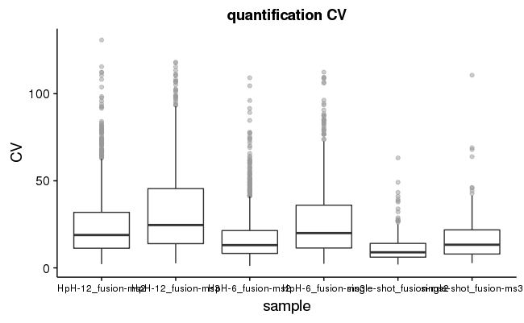

```r
peps = readRDS('/projects/ptx_analysis/chughes/projects-current/raw-quant/ms2-ms3/Routput/synthetic-peptide-quant-data.rds')
#make the plot for CV
cv_plot = ggplot(peps, aes(replicate,CV)) +
 geom_boxplot(outlier.color = 'gray60',outlier.alpha=0.5) +
  #geom_point(size=4,color='gray60',alpha=0.75) +
  labs(x = "sample", y = 'CV', title = 'quantification CV') +
  theme(axis.text.x = element_text(size = 9))
  #scale_y_continuous(limits=c(18000,24000))
cv_plot #call the plot
save_plot('/projects/ptx_analysis/chughes/projects-current/raw-quant/ms2-ms3/Routput/ch_synthetic-peptides-CV-all-methods.pdf',cv_plot) #output the plot
```

Interesting. The CV’s are lower for the MS2 data. This is likely the result of the SD not differing between the two approaches, but the mean being larger in the MS2 data (greater error). We can plot that as well.

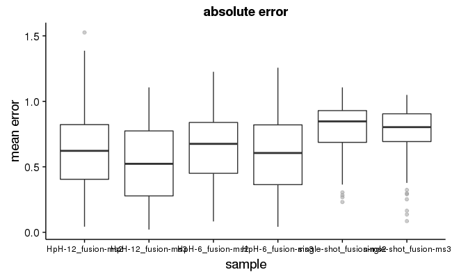

```r
peps = readRDS('/projects/ptx_analysis/chughes/projects-current/raw-quant/ms2-ms3/Routput/synthetic-peptide-quant-data.rds')
#make the plot for CV
err_plot = ggplot(peps, aes(replicate,errorMEAN)) +
 geom_boxplot(outlier.color = 'gray60',outlier.alpha=0.5) +
  #geom_point(size=4,color='gray60',alpha=0.75) +
  labs(x = "sample", y = 'mean error', title = 'absolute error') +
  theme(axis.text.x = element_text(size = 9))
err_plot #call the plot
save_plot('/projects/ptx_analysis/chughes/projects-current/raw-quant/ms2-ms3/Routput/ch_synthetic-peptides-error-all-methods.pdf',err_plot) #output the plot
```

Ok so the error is higher for MS2. Not unexpected. But, does this negatively impact our ability to pull out hits we know are varying (e.g. synthetic peptides)?

```r
ms2_set = readRDS('/projects/ptx_analysis/chughes/projects-current/raw-quant/ms2-ms3/Routput/all-ms2-id-quant-data.rds') #grab the ms2 data
ms3_set = readRDS('/projects/ptx_analysis/chughes/projects-current/raw-quant/ms2-ms3/Routput/all-ms3-id-quant-data.rds') #grab the ms3 data
ms_set = rbind(ms2_set,ms3_set) #bind all of the data together
speps = read.table('/projects/ptx_analysis/chughes/projects-current/raw-quant/ms2-ms3/Routput/ch_31906-31907-32033_libraries.txt',header=TRUE,sep='\t') #grab the synthetic peptide libraries
colnames(speps)[1:2] = c('gene','sequence') #change the column names for merging
ms_set$standard = 'no' #add annotation to track the standard peptides
ms_set[(ms_set$gene %in% speps$gene) & (ms_set$sequence %in% speps$sequence),27] = 'yes' #find the synthetic peptide entries
peps = merge(ms_set,speps,by=c('gene','sequence'),all.x=TRUE) #merge the data
peps_sub = subset(peps, (totalSN > 100) & (totalNA == 0) & !is.na(peps$Library)) #filter the data to remove low abundance and noisy hits
#iterate over the methods to do stats one at a time
method_type = unique(peps_sub$replicate) #get a list of the methods for analysis
speps_set = data.frame() #data storage object
for (l in 1:length(method_type)){
  work_set = subset(peps_sub, replicate == method_type[l])
  #calculate differential expression using limma
  #focus on library refA and refC, because these are the two opposites
  peps_no_refC = work_set[!grepl('refB',work_set$Library), ]
  eset = as.matrix(log2(peps_no_refC[,c(17:22)])) #log transform the expression data and transfer to a new object
  design <- cbind(condA=c(1,1,1,0,0,0),condB=c(0,0,0,1,1,1)) #create the design matrix
  fit <- lmFit(eset,design) #calculate the linear model of the expression values
  cont.matrix <- makeContrasts(condAvscondB=condA-condB, levels=design) #create the contrasts matrix
  fit2 <- contrasts.fit(fit, cont.matrix) #calculate the contrasts
  fit2 <- eBayes(fit2) #empirical Bayes smoothing
  logFC = fit2$coef #extract fold changes
  pVal = fit2$p.value #extract p-values
  p.adj = p.adjust(fit2$p.value, method="BH") #apply multiple testing correction to the p-values
  #insert the data back into the original matrix
  peps_no_refC$logFC <- logFC
  peps_no_refC$p.value <- pVal
  peps_no_refC$p.adj.value <- p.adj
  peps_no_refC_ord = peps_no_refC[order(-peps_no_refC$logFC),] #reorder the matrix by fold change
  refAB_set = subset(peps_no_refC_ord, standard == 'yes')
  #focus on library refB
  peps_no_refAB = work_set[!grepl('refA',work_set$Library) & !grepl('refC',work_set$Library), ]
  eset = as.matrix(log2(peps_no_refAB[,c(17:22)])) #log transform the expression data and transfer to a new object
  design <- cbind(condA=c(1,0,1,0,1,0),condB=c(0,1,0,1,0,1)) #create the design matrix
  fit <- lmFit(eset,design) #calculate the linear model of the expression values
  cont.matrix <- makeContrasts(condAvscondB=condA-condB, levels=design) #create the contrasts matrix
  fit2 <- contrasts.fit(fit, cont.matrix) #calculate the contrasts
  fit2 <- eBayes(fit2) #empirical Bayes smoothing
  logFC = fit2$coef #extract fold changes
  pVal = fit2$p.value #extract p-values
  p.adj = p.adjust(fit2$p.value, method="BH") #apply multiple testing correction to the p-values
  #insert the data back into the original matrix
  peps_no_refAB$logFC <- logFC
  peps_no_refAB$p.value <- pVal
  peps_no_refAB$p.adj.value <- p.adj
  peps_no_refAB_ord = peps_no_refAB[order(-peps_no_refAB$logFC),] #reorder the matrix by fold change
  refC_set = subset(peps_no_refAB_ord, standard == 'yes') #keep only standard peptides
  speps_set = rbind(speps_set,refAB_set,refC_set) #bind the data back together
}
saveRDS(speps_set,'/projects/ptx_analysis/chughes/projects-current/raw-quant/ms2-ms3/Routput/synthetic-peptide-stats-data.rds') #output the processed data
```

Now we can do some plotting of the data.

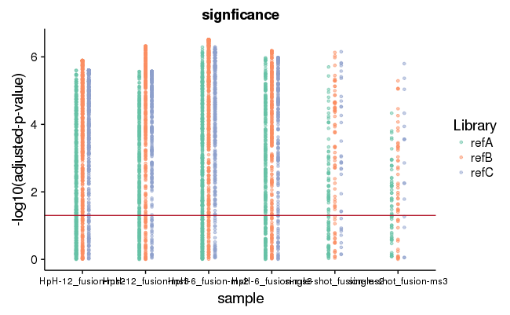

```r
peps = readRDS('/projects/ptx_analysis/chughes/projects-current/raw-quant/ms2-ms3/Routput/synthetic-peptide-stats-data.rds')
#make the plot for CV
sigi_plot = ggplot(peps, aes(replicate,-log10(p.adj.value))) +
 #geom_boxplot(outlier.color = 'gray60',outlier.alpha=0.5) +
  geom_point(aes(colour=Library),size=1,alpha=0.5,position=position_dodge(width=0.3)) +
  labs(x = "sample", y = '-log10(adjusted-p-value)', title = 'signficance') +
  theme(axis.text.x = element_text(size = 9)) +
  geom_hline(yintercept= -log10(0.05),color = brewer.pal(6,'RdBu')[1]) +
  scale_color_manual(values=brewer.pal(6,'Set2')[1:3])
  #theme(legend.position="none")
sigi_plot #call the plot
save_plot('/projects/ptx_analysis/chughes/projects-current/raw-quant/ms2-ms3/Routput/ch_synthetic-peptides-significance-all-methods.pdf',sigi_plot) #output the plot
```

```r
#calculate the proportions above and below the significant threshold
method_type = unique(peps$replicate) #get a list of the methods for analysis
for (i in 1:length(method_type)){
  work_set = subset(peps, replicate == method_type[i])
  message(method_type[i])
  message(length(work_set$p.adj.value))
  message(length(which(work_set$p.adj.value<0.05)))
}
```

```
HpH-12_fusion-ms2
1503
1199
HpH-12_fusion-ms3
1036
851
HpH-6_fusion-ms2
1212
1005
HpH-6_fusion-ms3
886
708
single-shot_fusion-ms3
128
84
single-shot_fusion-ms2
223
146
```

Do we get any significant hits from the regular HeLa peptides?

```r
ms2_set = readRDS('/projects/ptx_analysis/chughes/projects-current/raw-quant/ms2-ms3/Routput/all-ms2-id-quant-data.rds') #grab the ms2 data
ms3_set = readRDS('/projects/ptx_analysis/chughes/projects-current/raw-quant/ms2-ms3/Routput/all-ms3-id-quant-data.rds') #grab the ms3 data
ms_set = rbind(ms2_set,ms3_set) #bind all of the data together
speps = read.table('/projects/ptx_analysis/chughes/projects-current/raw-quant/ms2-ms3/Routput/ch_31906-31907-32033_libraries.txt',header=TRUE,sep='\t') #grab the synthetic peptide libraries
colnames(speps)[1:2] = c('gene','sequence') #change the column names for merging
ms_set$standard = 'no' #add annotation to track the standard peptides
ms_set[(ms_set$gene %in% speps$gene) & (ms_set$sequence %in% speps$sequence),27] = 'yes' #find the synthetic peptide entries
peps = merge(ms_set,speps,by=c('gene','sequence'),all.x=TRUE) #merge the data
peps_sub = subset(peps, (totalSN > 100) & (totalNA == 0)) #filter the data to remove low abundance and noisy hits
#iterate over the methods to do stats one at a time
method_type = unique(peps_sub$replicate) #get a list of the methods for analysis
speps_set = data.frame() #data storage object
for (l in 1:length(method_type)){
  work_set = subset(peps_sub, replicate == method_type[l])
  #calculate differential expression using limma
  peps_no_hela = work_set[grepl('no',work_set$standard), ]
  eset = as.matrix(log2(peps_no_hela[,c(17:22)])) #log transform the expression data and transfer to a new object
  design <- cbind(condA=c(1,1,1,0,0,0),condB=c(0,0,0,1,1,1)) #create the design matrix
  fit <- lmFit(eset,design) #calculate the linear model of the expression values
  cont.matrix <- makeContrasts(condAvscondB=condA-condB, levels=design) #create the contrasts matrix
  fit2 <- contrasts.fit(fit, cont.matrix) #calculate the contrasts
  fit2 <- eBayes(fit2) #empirical Bayes smoothing
  logFC = fit2$coef #extract fold changes
  pVal = fit2$p.value #extract p-values
  p.adj = p.adjust(fit2$p.value, method="BH") #apply multiple testing correction to the p-values
  #insert the data back into the original matrix
  peps_no_hela$logFC <- logFC
  peps_no_hela$p.value <- pVal
  peps_no_hela$p.adj.value <- p.adj
  hela_set = peps_no_hela[order(-peps_no_hela$logFC),] #reorder the matrix by fold change
  speps_set = rbind(speps_set,hela_set) #bind the data back together
}
saveRDS(speps_set,'/projects/ptx_analysis/chughes/projects-current/raw-quant/ms2-ms3/Routput/hela-peptide-stats-data.rds') #output the processed data
```

Now we can do some plotting of the data.

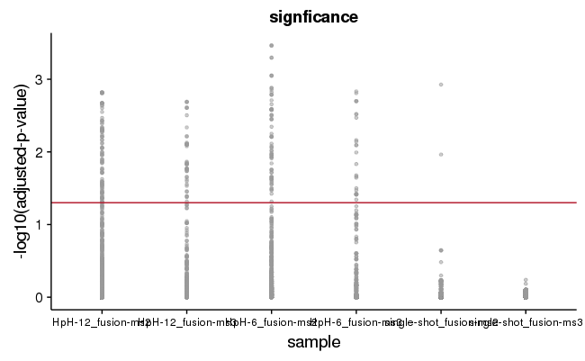

```r
peps = readRDS('/projects/ptx_analysis/chughes/projects-current/raw-quant/ms2-ms3/Routput/hela-peptide-stats-data.rds')
#make the plot for CV
sigi_plot = ggplot(peps, aes(replicate,-log10(p.adj.value))) +
 #geom_boxplot(outlier.color = 'gray60',outlier.alpha=0.5) +
  geom_point(colour='grey60',size=1,alpha=0.5) +
  labs(x = "sample", y = '-log10(adjusted-p-value)', title = 'signficance') +
  theme(axis.text.x = element_text(size = 9)) +
  geom_hline(yintercept= -log10(0.05),color = brewer.pal(6,'RdBu')[1])
sigi_plot #call the plot
save_plot('/projects/ptx_analysis/chughes/projects-current/raw-quant/ms2-ms3/Routput/ch_hela-peptides-significance-all-methods.pdf',sigi_plot) #output the plot
```

```r
#calculate the proportions above and below the significant threshold
method_type = unique(peps$replicate) #get a list of the methods for analysis
for (i in 1:length(method_type)){
  work_set = subset(peps, replicate == method_type[i])
  message(method_type[i])
  message(length(work_set$p.adj.value))
  message(length(which(work_set$p.adj.value<0.05)))
}
```

```
HpH-12_fusion-ms2
140590
116
HpH-12_fusion-ms3
88433
52
HpH-6_fusion-ms2
99719
76
HpH-6_fusion-ms3
64983
26
single-shot_fusion-ms2
18416
2
single-shot_fusion-ms3
11408
0
```

Done.